# Lab 3

Ted Henson

September 17, 2018

# Instructions

**Exercises:** 1,3 (Pgs. 90-91); 1 (Pg. 93); 2,4 (Pg. 99); 1,2 (Pg. 101); 2,3,5 (Pg. 104)

**Assigned:** Friday, September 14, 2018

**Due:** Friday, September 21, 2018 by 5:00 PM

**Submission:** Submit via an electronic document on Sakai. Must be submitted as a HTML file generated in RStudio. All assigned problems are chosen according to the textbook *R for Data Science*. You do not need R code to answer every question. If you answer without using R code, delete the code chunk. If the question requires R code, make sure you display R code. If the question requires a figure, make sure you display a figure. A lot of the questions can be answered in written response, but require R code and/or figures for understanding and explaining.

# Chapter 5 (Pgs. 90-91)

## Exercise 1

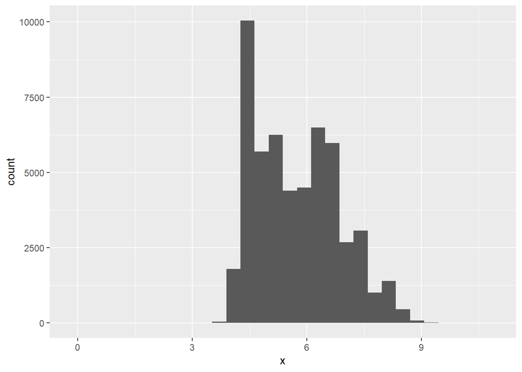

```r
ggplot(diamonds) + geom_histogram(mapping = aes(x = x))
```

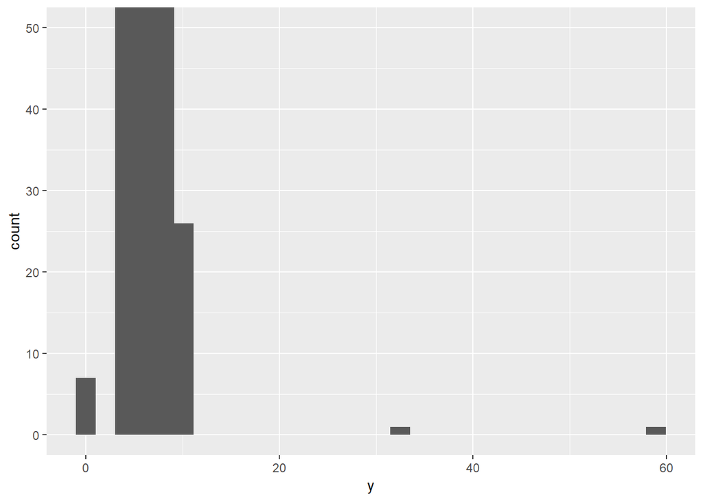

```r
ggplot(diamonds) + geom_histogram(mapping = aes(x = y)) + coord_cartesian(ylim = c(0, 50))
```

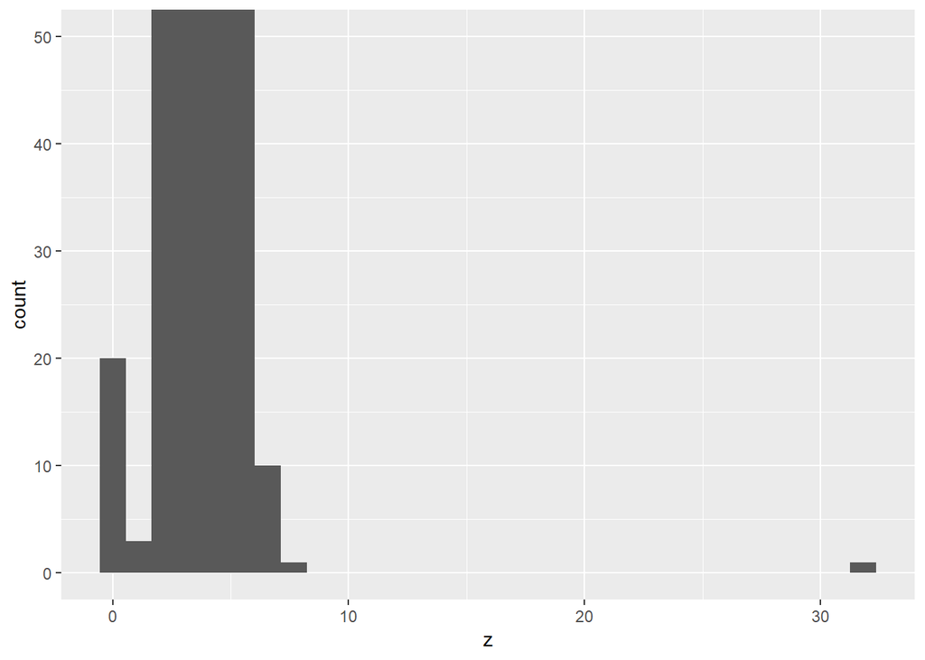

```r
ggplot(diamonds) + geom_histogram(mapping = aes(x = z)) + coord_cartesian(ylim = c(0, 50))
```

```r
head(diamonds)
```

```
## # A tibble: 6 x 10
##   carat cut       color clarity depth table price     x     y     z
##   <dbl> <ord>     <ord> <ord>   <dbl> <dbl> <int> <dbl> <dbl> <dbl>
## 1 0.23  Ideal     E     SI2      61.5    55   326  3.95  3.98  2.43
## 2 0.21  Premium   E     SI1      59.8    61   326  3.89  3.84  2.31
## 3 0.23  Good      E     VS1      56.9    65   327  4.05  4.07  2.31
## 4 0.290 Premium   I     VS2      62.4    58   334  4.2   4.23  2.63
## 5 0.31  Good      J     SI2      63.3    58   335  4.34  4.35  2.75
## 6 0.24  Very Good J     VVS2     62.8    57   336  3.94  3.96  2.48
```

```r
#
```

The y and z variables appear to have some large values, whereas the x variable does not appear to go over 10.

## Exercise 3

```r
sum(diamonds$carat == .99)
```

```
## [1] 23
```

```r
sum(diamonds$carat == 1)
```

```
## [1] 1558
```

```r
#
```

There are more 1 carat diamonds because people want to talk about their diamond and say ‘this diamond is 1 carat’ rather than .99.

# Chapter 5 (Pg. 93)

## Exercise 1

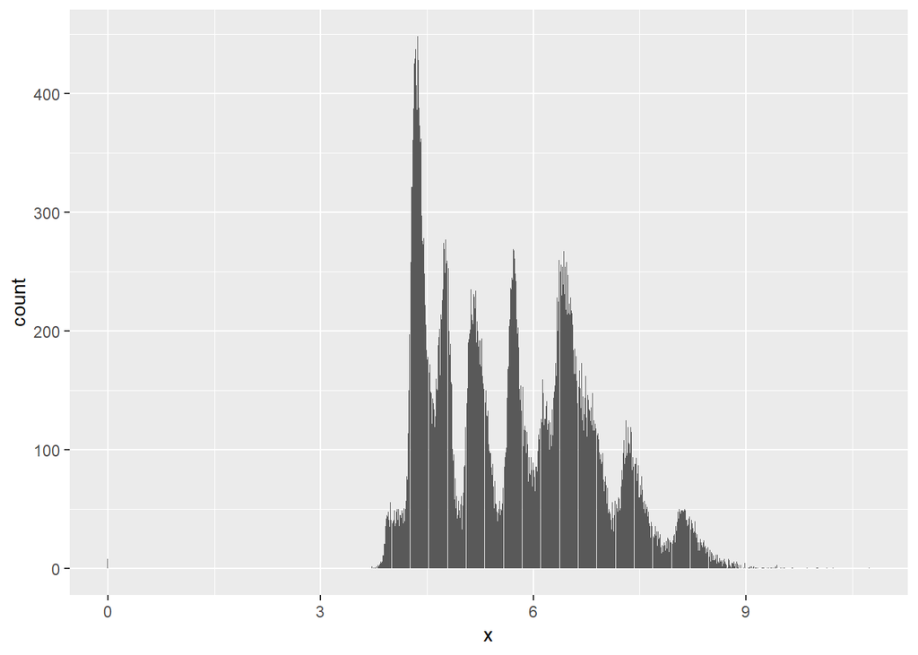

```r
ggplot(diamonds, mapping = aes(x = x)) + geom_bar()
```

```r
#
```

Missing values are not put in the histogram, but a warning message is placed at the bottom letting you know that there were some missing values. In a bar chart the values are included.

# Chapter 5 (Pg. 99)

## Exercise 2

```r
numericdiamonds <- diamonds %>% select(carat, depth, table, price, x, y, z)
cor(numericdiamonds)
```

```
##            carat       depth      table      price           x           y
## carat 1.00000000  0.02822431  0.1816175  0.9215913  0.97509423  0.95172220
## depth 0.02822431  1.00000000 -0.2957785 -0.0106474 -0.02528925 -0.02934067
## table 0.18161755 -0.29577852  1.0000000  0.1271339  0.19534428  0.18376015
## price 0.92159130 -0.01064740  0.1271339  1.0000000  0.88443516  0.86542090
## x     0.97509423 -0.02528925  0.1953443  0.8844352  1.00000000  0.97470148
## y     0.95172220 -0.02934067  0.1837601  0.8654209  0.97470148  1.00000000
## z     0.95338738  0.09492388  0.1509287  0.8612494  0.97077180  0.95200572
##                z
## carat 0.95338738
## depth 0.09492388
## table 0.15092869
## price 0.86124944
## x     0.97077180
## y     0.95200572
## z     1.00000000
```

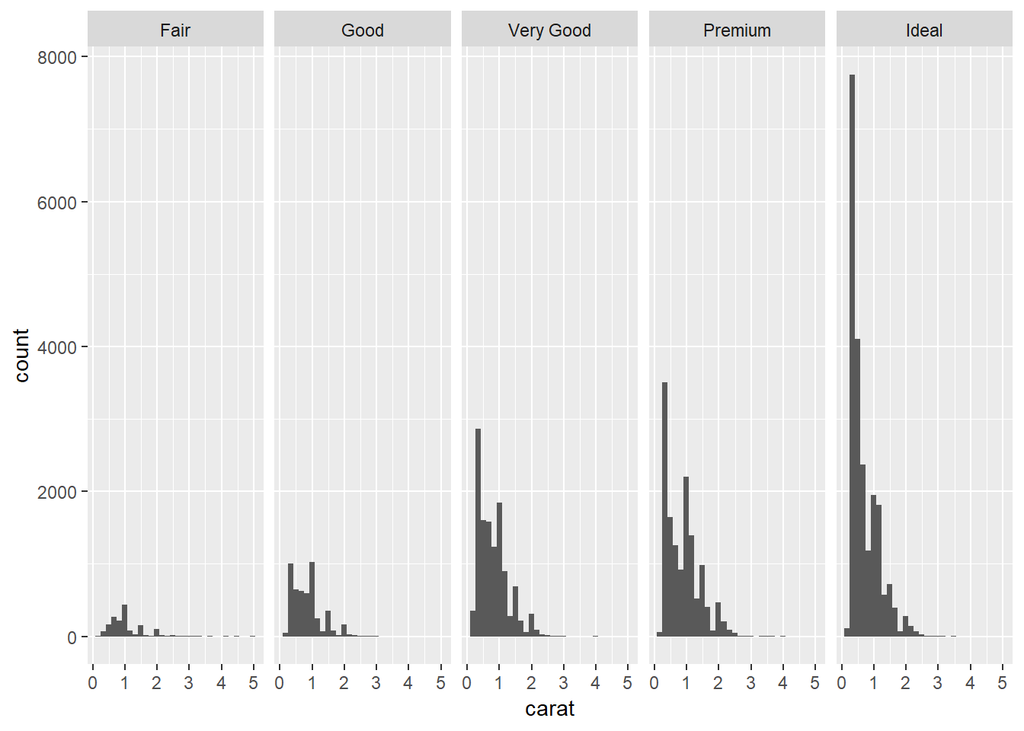

```r
ggplot(diamonds, aes(x = carat)) + geom_histogram() + facet_grid(~cut)
```

```r
#
```

The carat variable is the most important for predicting the price of the diamond. It is directly related to the cut of the diamond. Some lower quality diamonds are big so they are still expensive.